# GAM modelling with mgcv

Matteo Fasiolo

September 23 2019

The `mgcv` R package offers tools for building and fitting GAMs, using the methods described in [Wood, 2017](https://www.crcpress.com/Generalized-Additive-Models-An-Introduction-with-R-Second-Edition/Wood/p/book/9781498728331). The main fitting function is `gam()`, which fits an GAM models and returns an object of class `gam`. See `?gamObject`.

# An additive example with four covariates

We simulate some data from the model:
$$y = f_0(x_0)+f_1(x_1)+f_2(x_2)+f_3(x_3)+e,\;\;\; e \sim N(0, 2)$$
by doing

```r
library(mgcv)
set.seed(2)
dat <- gamSim(1, n=1000, dist="normal", scale=2)[c("y", "x0", "x1", "x2", "x3")]
```

```
## Gu & Wahba 4 term additive model
```

We start by fitting a Gaussan linear model:

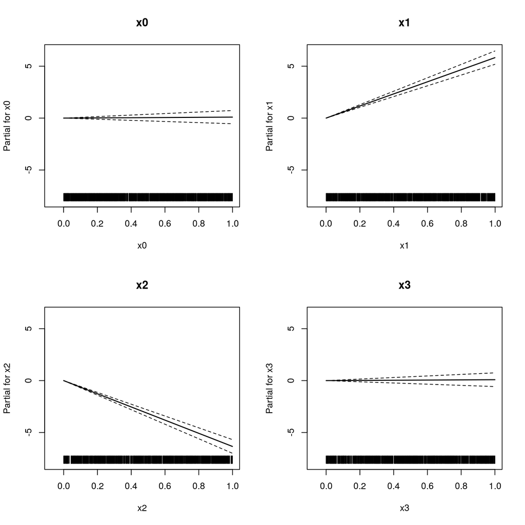

```r
fit1 <- gam(y ~ x0 + x1 + x2 + x3,
            family = gaussian,
            data = dat)

plot(fit1, all.terms = TRUE, pages = 1) # plot() calls plot.gam(). See ?plot.gam
```

We use `pages = 1` to plot on a single page, and `all.terms` to plot also the parametric effects (the plotting method used here plots only smooth or random effects by default).

Should we use a smooth effect of `x2`? If the effect of `x2` was non-linear, we would expect that the mean of the residuals would depart from 0, as we move along `x2`. We can use a marginal residual check:

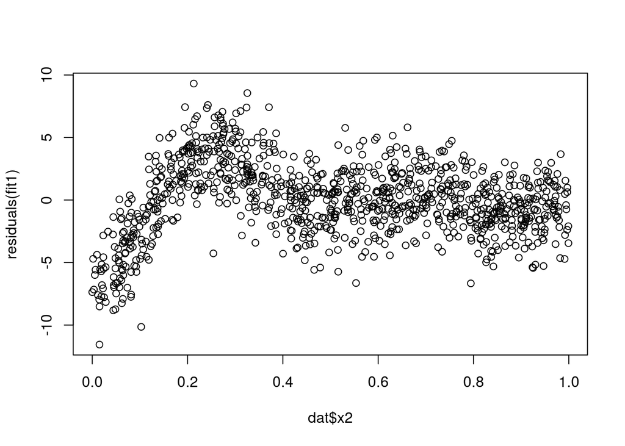

```r
plot(dat$x2, residuals(fit1))
```

There is definitively a pattern here. An analogous plot along `x0` also shows a residual pattern, hence we consider the model:

```r
fit2 <- gam(y ~ s(x0, k = 10) + x1 + s(x2, k = 10) + x3,
             data = dat)
```

Leads to much lower AIC:

```r
AIC(fit1, fit2)
```

```
##           df      AIC
## fit1  6.0000 5031.867
## fit2 15.9842 4288.974
```

Get QQ-plot of residuals looks fine:

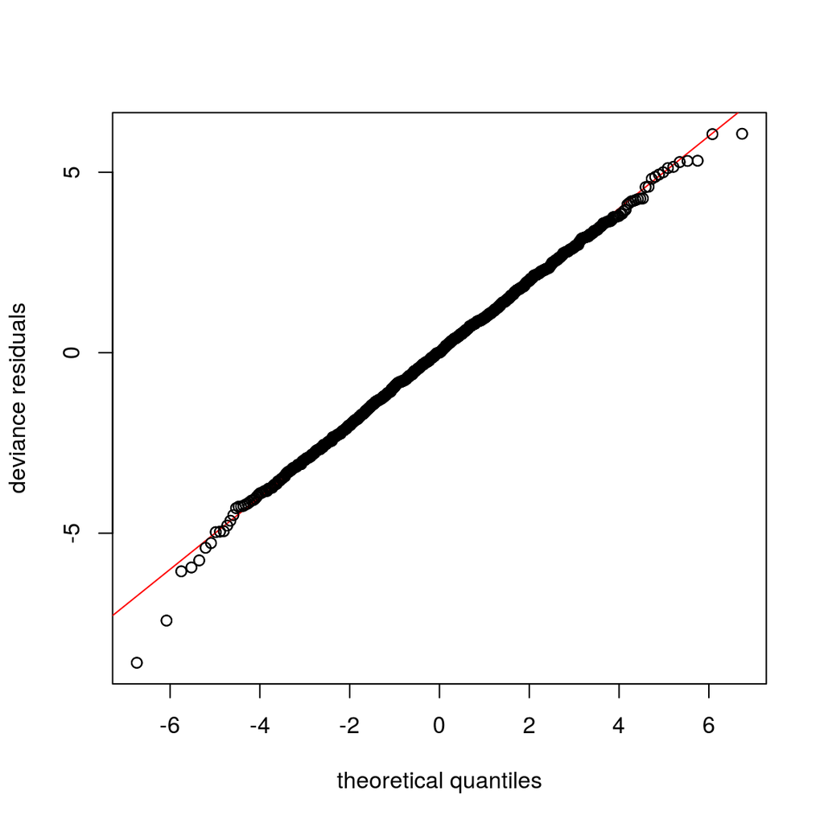

```r
qq.gam(fit2, pch = 1)
```

Now we check whether spline bases were large enough:

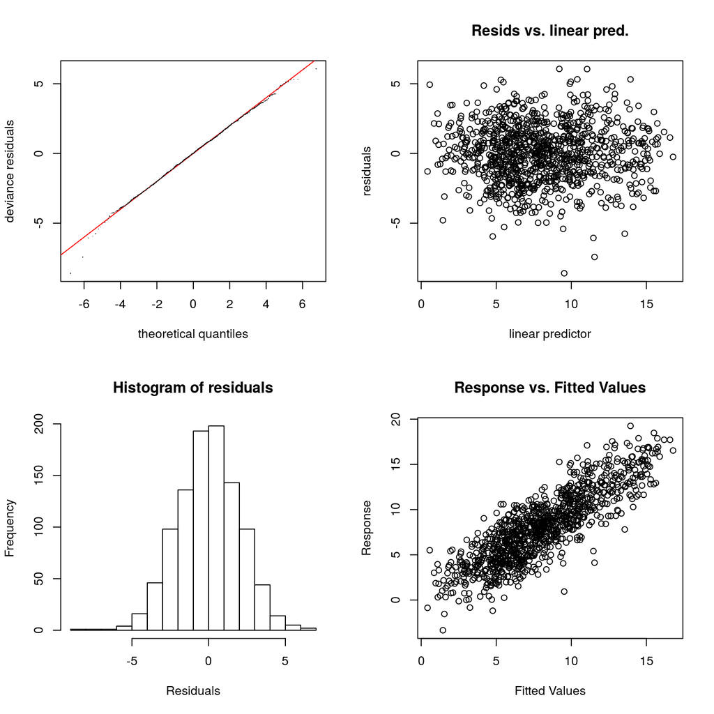

```
##
## Method: GCV   Optimizer: magic
## Smoothing parameter selection converged after 7 iterations.
## The RMS GCV score gradient at convergence was 2.269429e-06 .
## The Hessian was positive definite.
## Model rank =  21 / 21
##
## Basis dimension (k) checking results. Low p-value (k-index<1) may
## indicate that k is too low, especially if edf is close to k'.
##
##         k'  edf k-index p-value
## s(x0) 9.00 3.61    0.98    0.18
## s(x2) 9.00 8.37    1.02    0.70
```

```r
gam.check(fit2)
```

Maybe we should increase `k` for `x2`.

We can plot all the smooth effects by doing:

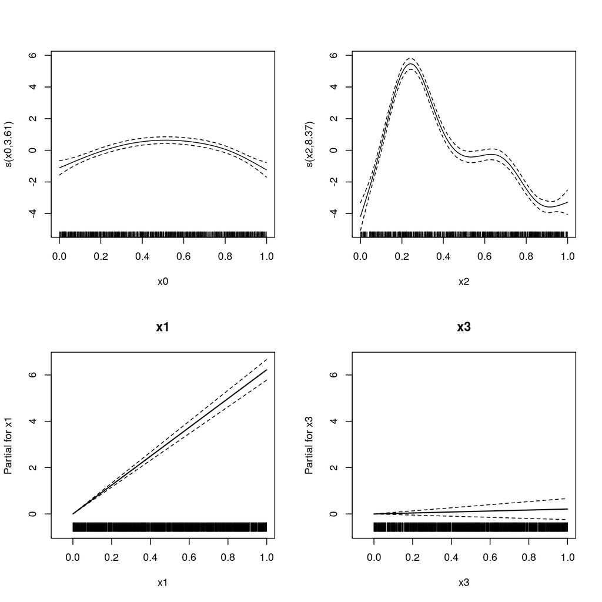

```r
plot(fit2, all.terms = TRUE, pages = 1)
```

To print only the second we do:

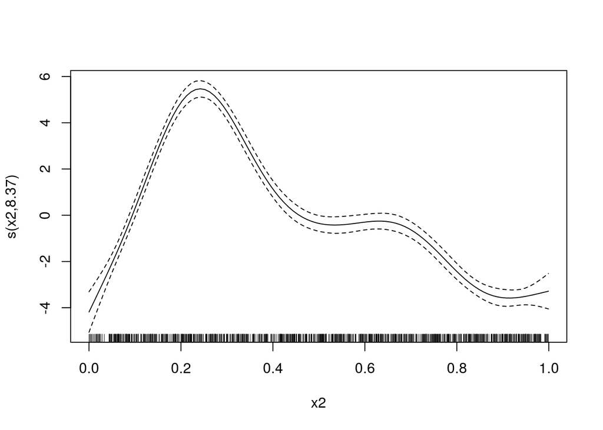

```r
plot(fit2, select = 2)
```

We get p-values etc by doing:

```r
summary(fit2)
```

```
##
## Family: gaussian
## Link function: identity
##
## Formula:
## y ~ s(x0, k = 10) + x1 + s(x2, k = 10) + x3
##
## Parametric coefficients:
##             Estimate Std. Error t value Pr(>|t|)
## (Intercept)   4.7538     0.1715  27.724   <2e-16 ***
## x1            6.2244     0.2225  27.970   <2e-16 ***
## x3            0.2116     0.2278   0.929    0.353
## ---
## Signif. codes:  0 '***' 0.001 '**' 0.01 '*' 0.05 '.' 0.1 ' ' 1
##
## Approximate significance of smooth terms:
##         edf Ref.df      F  p-value
## s(x0) 3.612  4.474  17.23 1.18e-14 ***
## s(x2) 8.373  8.891 205.73  < 2e-16 ***
## ---
## Signif. codes:  0 '***' 0.001 '**' 0.01 '*' 0.05 '.' 0.1 ' ' 1
##
## R-sq.(adj) =  0.722   Deviance explained = 72.6%
## GCV = 4.2602  Scale est. = 4.1964    n = 1000
```

# References

Wood S. N. (2017) Generalized additive models: an introduction with R. Second edition. Chapman and Hall/CRC, 2017.